# A simple app to study mortality data for Hungary.

Albert de Roos  
31 May 2016

## Background and Rationale

### Mortality data

- the World Health Organization publishes mortality data for a large number of countries over the last 50 years
- this mortality data gives insight in the causes of death and the differences in regions leading to better insight in the causes of disease
- a good graphical presentation of this dat can help in visualizing mortality trends

### A shiny app for mortality data

- we developed a proof-of-concept for visualing the mortality trends using a shiny app
- here we show the R code and shiny server and ui code that was used
- we show a simple app where the user can select the year and the mortality-age group distrbution is show

### Slide With Code

## Shiny ui.R

- We used a simple layout with header, sidebar and main panels
- We used a simple slider to indicate the year to display
- Code is abbreviated and more text is shown in the app itself

```r
shinyUI(pageWithSidebar(
     headerPanel('Pharynx Cancer Mortality Data From Hungary'),
     sidebarPanel(
          p("Use the slider to see the different mortality rate distribution"),
          sliderInput("year", "Choose the year:", min=1955, max=2012, value=1995, sep = "")),
     mainPanel(
          p("Explanatory text here"),
          plotOutput('plot1')
     )
))
```

### Slide With Code

## Shiny server.R and global.R code

- Server code used a ggplot2 grap based on the input year
- We needed an extra file global.R to download the data (not shown)
- The original mortality files contained data on pharynx cancer per year and per age group.
- The input data was melted using dplyr to get tidy data as input for the app.

```r
shinyServer(function(input, output, session) {

     output$plot1 <- renderPlot({
          graph <- graphdata[graphdata$Year == input$year, 2:3]
          ggplot(data=graph, aes(x=AgeGroup, y=MortRate, group = 1)) +
               ggtitle("Hungary: Mortality Rates by Age Group") + xlab("Age Group") +
               ylab("Mortality Rate") +
               geom_point() +
               geom_line() +
               theme(axis.text.x = element_text(angle = 45)) +
               ylim(0,120)
     })
})
```

### Slide With Plot

## The Result: The Mortality Data App

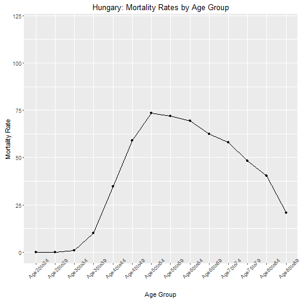